# The relations between Prosper Rating and other parameters

## by Hatem Mohammed Kamal

## Investigation Overview

> In this investigation, I wanted to know the relation between Prosper Rating categories and some other variables in the data set.

## Dataset Overview

> a 113937 rows * 81 columns data about loans and the details related to borrower and the loan itself.

## Count of people choosing each prosper rating category

> more people tend to have a moderate level of risk with there investments or loans

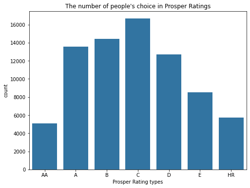

```python
plt.figure(figsize=(8, 6))
base_color = sns.color_palette()[0]
order = ['AA', 'A', 'B', 'C', 'D', 'E', 'HR']
sns.countplot(x=interest_df['ProsperRating (Alpha)'], order = order, color=base_color);
plt.title("The number of people's choice in Prosper Ratings");
plt.ylabel('count')
plt.xlabel('Prosper Rating types');
```

## the Count of people with each Income Range over every Prosper Rating type

> we see here people with 100+K income tend to choose plan A and B, and from 75K-100K goes for A,B and C, 50-75K choose C more, and 25-50 tends to go for higher risks more to C and D, and 1-25K tends to choose higher risks and goes for C,D,E and HR with almost the same amount

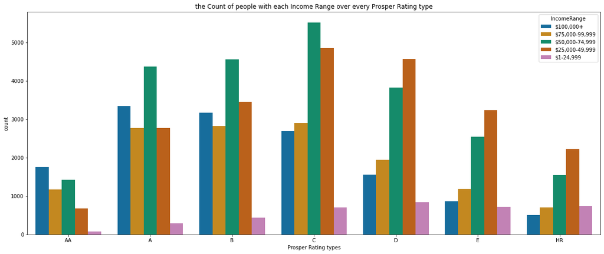

```python
plt.figure(figsize=(20,8))
order_income = ['$100,000+', '$75,000-99,999', '$50,000-74,999',
                '$25,000-49,999', '$1-24,999']
sns.countplot(data = interest_df, x = 'ProsperRating (Alpha)',
              hue = 'IncomeRange', order=order, hue_order=order_income,
              palette=sns.color_palette('colorblind'));
plt.title('the Count of people with each Income Range over every Prosper Rating type');
plt.xlabel('Prosper Rating types');
plt.ylabel('count');
```

## the Destrebution of Debt To Income Ratio over every Prosper Rating type

> We see here that as we get more risky plans we se the majorety of Debt to income ration goes up

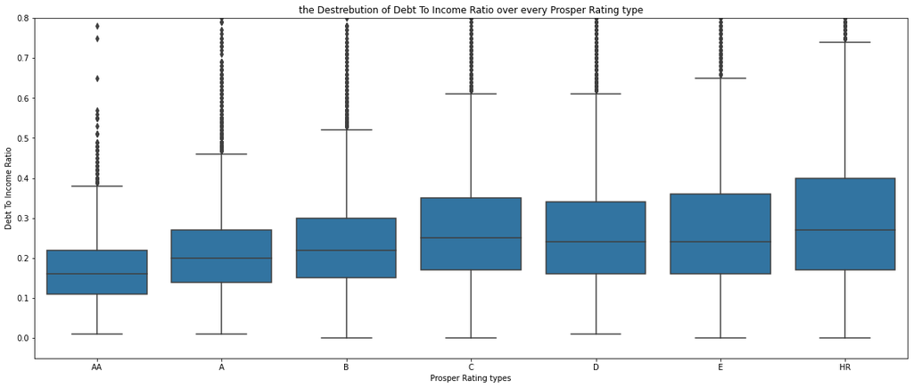

```python
plt.figure(figsize=(20,8))
sns.boxplot(data=interest_df, x='ProsperRating (Alpha)', y='DebtToIncomeRatio',
            color=base_color, order=order);
plt.ylim((-0.05, 0.8));
plt.title('the Destrebution of Debt To Income Ratio over every Prosper Rating type');
plt.xlabel('Prosper Rating types');
plt.ylabel('Debt To Income Ratio');
```

## The relation between APR and Debt To Income Ratio categorized with Income Range

> we see that as we get less income range we see more dept to income ratio. We also see here people with 1-25K income range have strange values compared to others

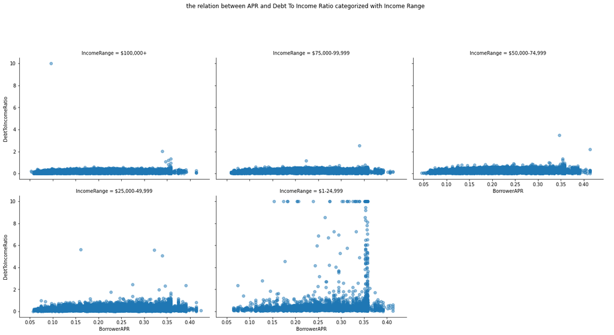

```python
g = sns.FacetGrid(data = interest_df, col = 'IncomeRange', margin_titles = True,
                  col_order=order_income, palette=sns.color_palette('bright'),
                  height=5, aspect=1.2, col_wrap=3);
g.map(plt.scatter, 'BorrowerAPR', 'DebtToIncomeRatio', alpha=0.5);
g.add_legend();
plt.subplots_adjust(top=0.82);
g.fig.suptitle('the relation between APR and Debt To Income Ratio categorized with Income Range');
```

# the relation between APR and Debt To Income Ratio (Income Rang = 1-25K)

> Here the prosper rating of HR has the most strange values at 0.36 APR. also we see this strange values at D and E Prosper Rate

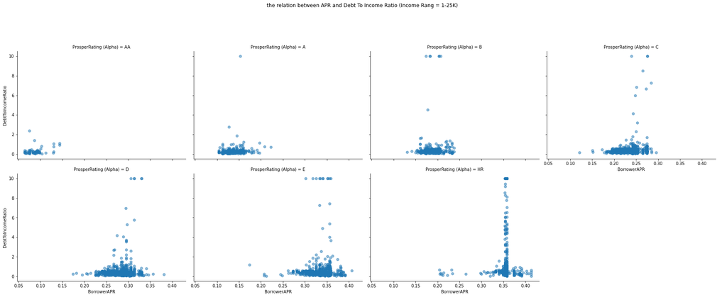

```python
df_range = interest_df[(interest_df.IncomeRange=='$1-24,999')]
g = sns.FacetGrid(data = df_range, col = 'ProsperRating (Alpha)',
                  margin_titles = True, col_order=order,
                  palette=sns.color_palette('bright'), height=5, aspect=1.2,
                  col_wrap=4);
g.map(plt.scatter, 'BorrowerAPR', 'DebtToIncomeRatio', alpha=0.5);
g.add_legend()
#plt.title('the relation between APR and Debt To Income Ratio (Income Rang = 1-25K)');
plt.subplots_adjust(top=0.82);
g.fig.suptitle('the relation between APR and Debt To Income Ratio (Income Rang = 1-25K)');
```

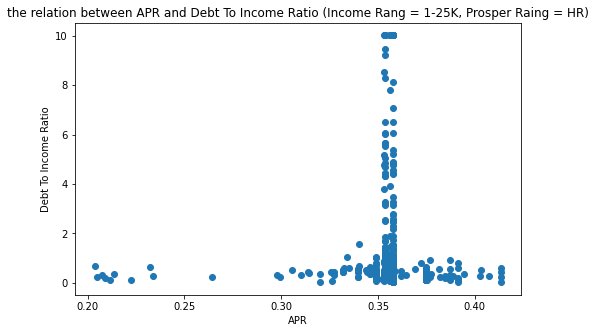

```python
plt.figure(figsize=(8,5));
df_range = interest_df[(interest_df.IncomeRange=='$1-24,999') & (interest_df['ProsperRating (Alpha)']==('HR'))]
plt.scatter(data=df_range, x='BorrowerAPR', y='DebtToIncomeRatio', color=base_color);
plt.title('the relation between APR and Debt To Income Ratio (Income Rang = 1-25K, Prosper Raing = HR)');
plt.xlabel('APR');
plt.ylabel('Debt To Income Ratio');
```